# Fuzzy action: 3rd pilot

## Experiment

165 participants were recruited via MTurk on March 30 2016 and paid 0.35 US-Dollar compensation.

Each participant interpreted 1 description for 6 scenarios by adjusting a slider bar. They also rated the naturalness of the description on a 7-point Likert scale. Scenarios and descriptions were presented at random. No two scenarios or descriptions were shown twice.

Scenarios:

1. US male: *tall* vs *short*
2. bath: *hot* vs *cold*
3. movie: *long* vs *short*
4. laptop: *expensive* vs *cheap*
5. band: *full* vs *empty*
6. car: *fast* vs *slow*

Here, “P” is either *tall* and “Q” is *short* for scenario “US male”.

## Questions of interest

1. Is there a coherent rank order among these descriptions? What is it?
   - e.g., is “not-Q” interpreted as higher than “neither P nor Q”?
2. Is there a correlation between the naturalness ratings and the variance in interpretation (by-scenario & by-description)?
3. Is there lower variance in interpretation for “P and not-P” vs “neither P nor not P”?
4. Does predicate type (stage-level vs. individual-level) have an effect on naturalness ratings? Here, we care especially for borderline contradictions.

## Exclude some participants

We exclude 4 participants as not being self-reported native English speakers. We have a total of 161 participants. This gives us an expectation of 17.89 answers per scenario-description pair.

## Vizualize results

Interpretations:

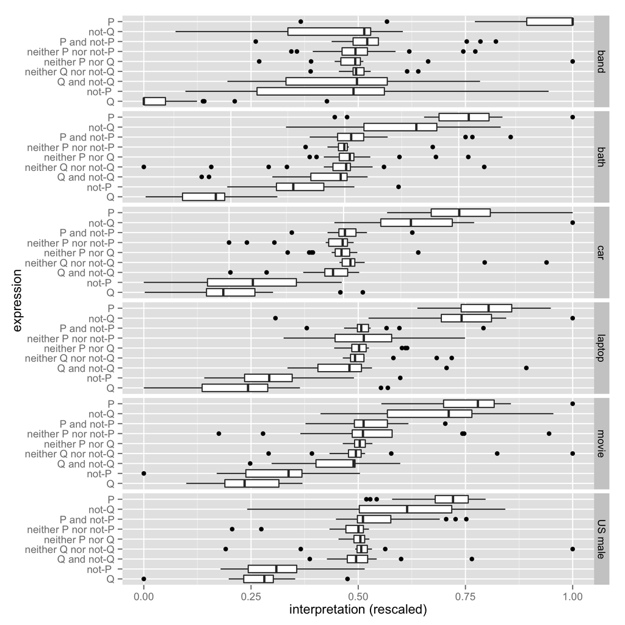

Ranks of means of interpretations, plotted against “expectation”:

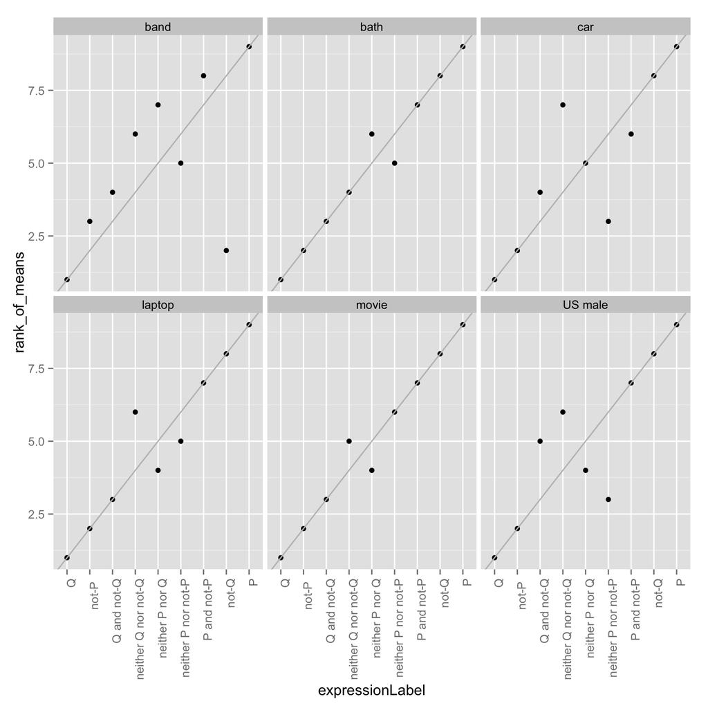

Rank order of means of interpretations, by scenario:

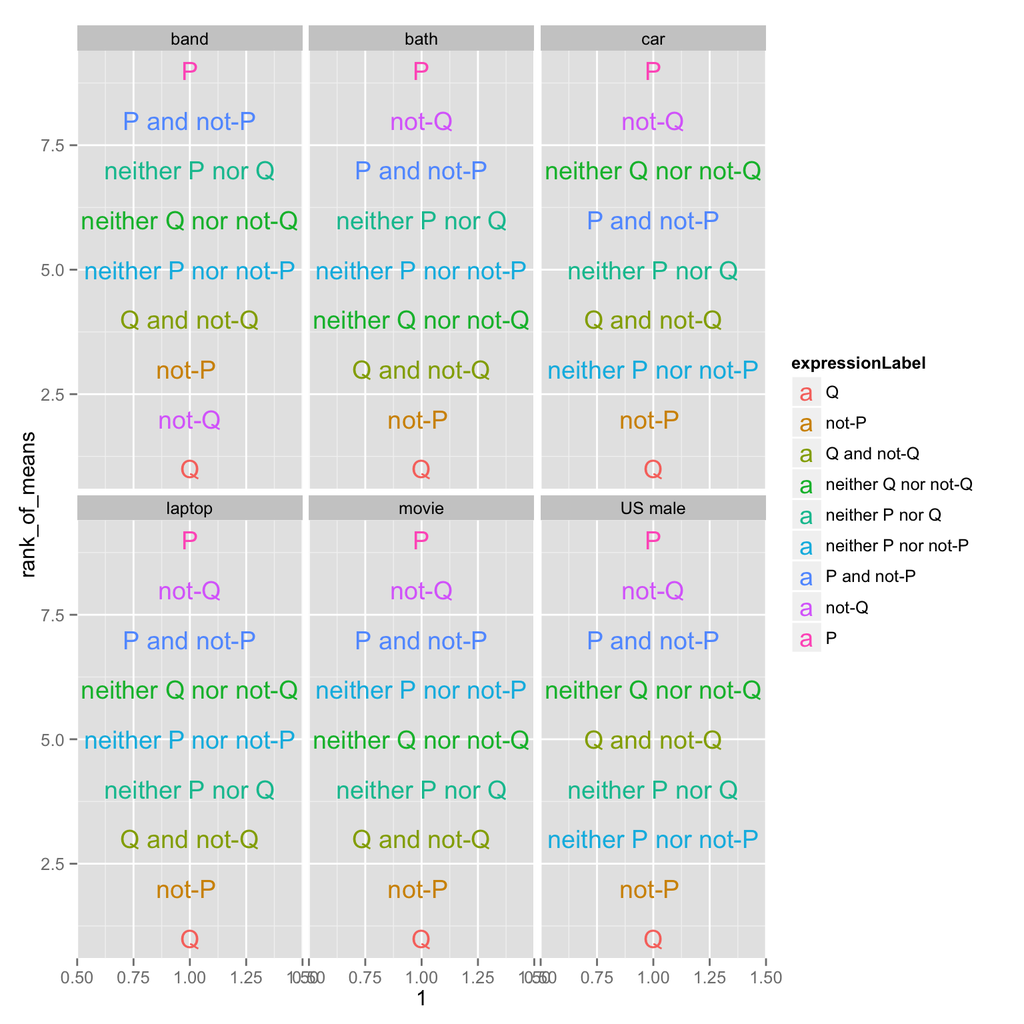

Naturalness ratings:

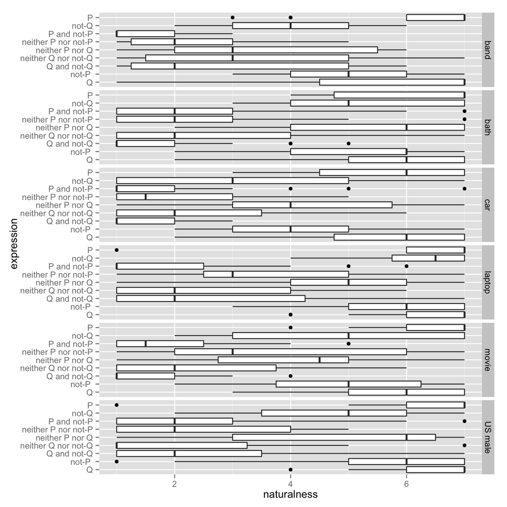

Rank order of naturalness ratings:

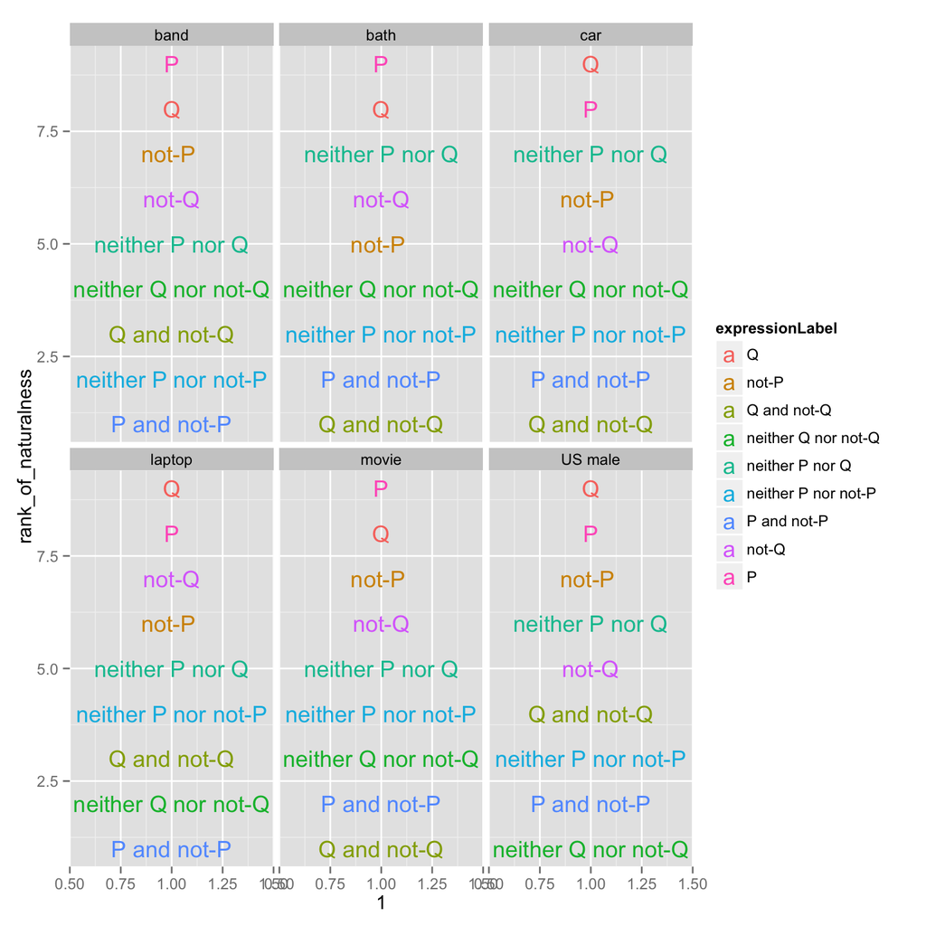

Variance in interpretations against naturalness:

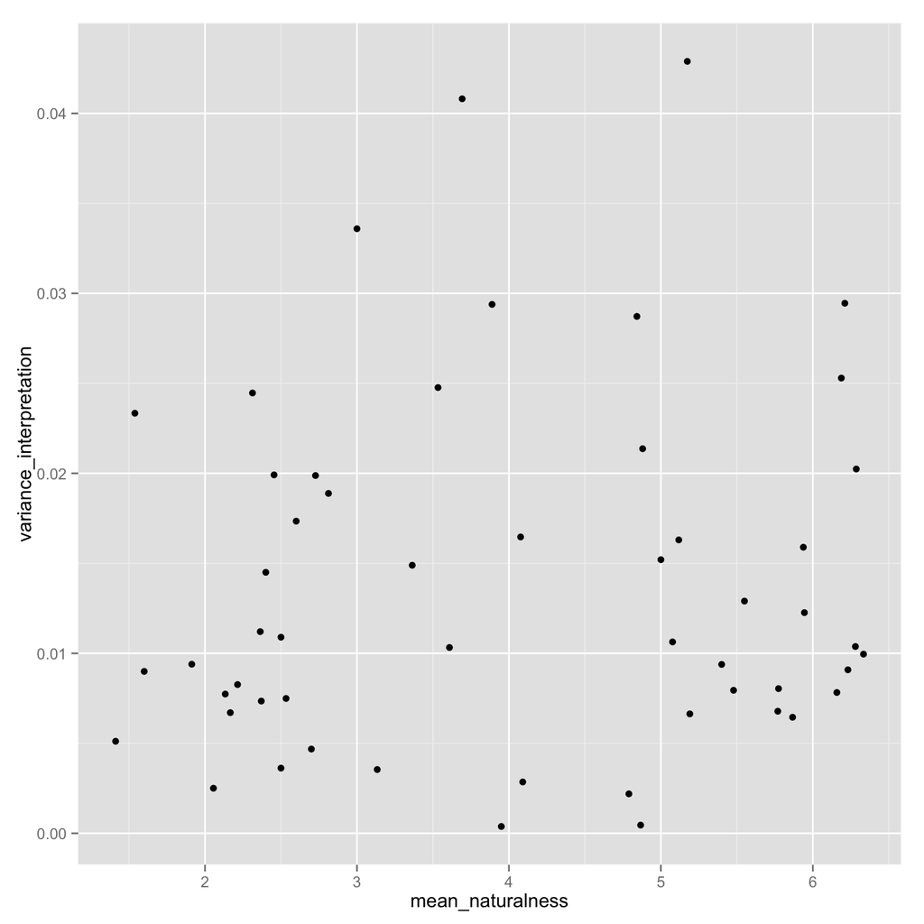